# Introduction to Linear Regression

Managerial Statistics - ECON 730

## Objectives

- After this lecture you should be able to use linear regression
- Topics:
  - Classical assumptions of regression

## R Packages Used In This Lecture

```r
if (!require("tidyverse")) install.packages("tidyverse")
library(tidyverse)

if (!require("Rmisc")) install.packages("Rmisc")
library(Rmisc)

if (!require("psych")) install.packages("psych")
library(psych)
```

## Case Background: Autorama Car Dealership

- Autorama is opening a new dealership
- Management has asked us to help choose the inventory of cars by price range
- Management would like an prediction of the number of cars sold by price

## Assumptions of the Classical Linear Regression Model

1. The dependent variable is **linearly** related to the coefficients of the model and the model is correctly specified.
2. No perfect **multicollinearity.** No independent variable has a perfect linear relationship with any of the other independent variables.
3. The **mean** of the **error** term is **zero.**
4. The error term has a **constant variance.** No heteroscedasticity.
5. The error term is **normally distributed.** (Not absolutely necessary)
6. The error terms are **uncorrelated** with each other. No autocorrelation or serial correlation.
7. The **independent variable(s)** is/are **uncorrelated** with the equation **error term.**

The focus in this lecture will be on checking that dependent variable is **linearly** related independent variables, the error term (also call the residues) show no pattern, and that the error term (residues) is reasonably close to being normally distributed.

## Checking for a Linear Relationship

Anscombe’s Quartet of ‘Identical’ Simple Linear Regressions is a set of four pairs of x/y data that all yield identical regression output. Consider the summary statistics below.

```r
data("anscombe")
describe(anscombe, skew = F,ranges = F)
```

```
   vars  n mean   sd   se
x1    1 11  9.0 3.32 1.00
x2    2 11  9.0 3.32 1.00
x3    3 11  9.0 3.32 1.00
x4    4 11  9.0 3.32 1.00
y1    5 11  7.5 2.03 0.61
y2    6 11  7.5 2.03 0.61
y3    7 11  7.5 2.03 0.61
y4    8 11  7.5 2.03 0.61
```

But when the data is plotted, we see only one of the x/y pairs sows a linear relationship. Thus, simple linear regression is invalid for the other three pairs.

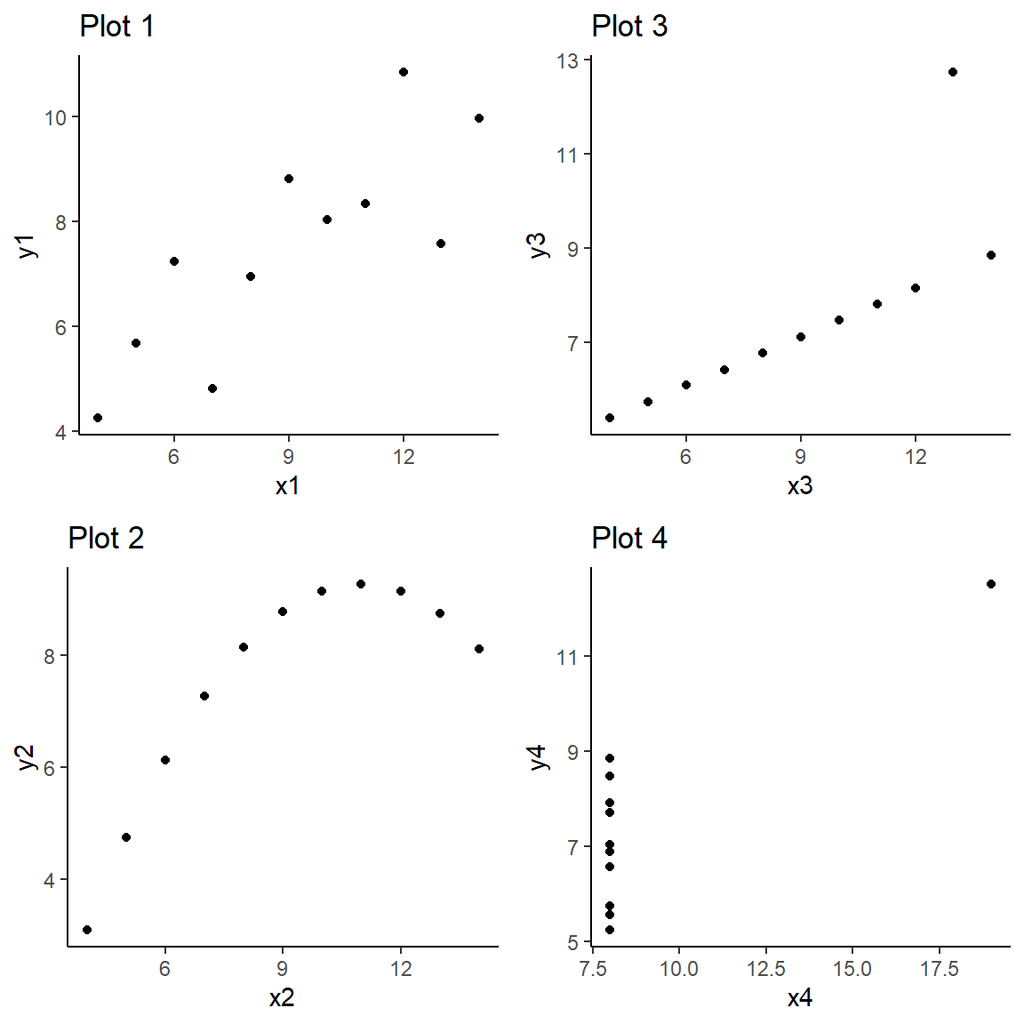

This data set was constructed in 1973 by the statistician Francis Anscombe to demonstrate the importance of graphing data before analyzing. Here is a short video on this very special data set.

[video not shown]

## Case: Autorama Car Dealership

The management of the Autorama Car Dealership has provided us with the following data:

- Buyer Income / Car price bought
- Percentage of people in each Income Bracket
- Nationwide data: Percentage of people who buy a new car in each income bracket in any given year

We first want to find a relationship between buyer income and the price of the car bought.

## Scatterplot of the Price Paid for Car vs. Cutomer Income

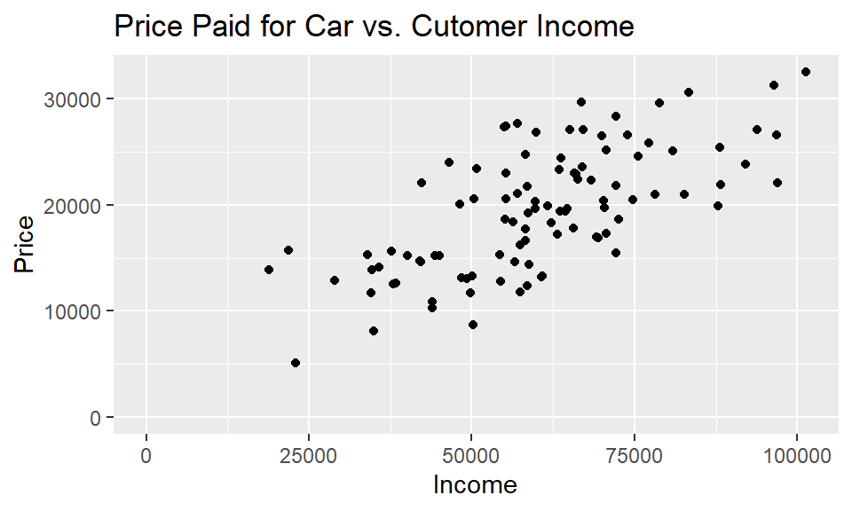

There appears to be a linear relationship between the two variables: price and income. But we also want to consider the summary statistics.

```
       vars   n  mean       sd   min    max range      se
Income    1 100 60359 17104.88 18900 101300 82400 1710.49
Price     2 100 19522  5759.36  5100  32500 27400  575.94
```

## A closser look at the code to draw the scaterplot

```r
# Load the tidyverse.
if (!require("tidyverse")) install.packages("tidyverse")
suppressMessages(library(tidyverse))

# Load the autorama data
car.price <- read.csv("data/autorama.csv")

# Use ggplot2 to draw the scaterplot
car.price %>% ggplot(aes(x=Income,y=Price)) +
  geom_point() +
  expand_limits(x = 0, y = 0) +
  ggtitle("Price Paid for Car vs. Cutomer Income")
```

## Estimate linear regression

In r, the `lm()` command is used to estimate linear regression models. The “lm” stands for linear model.

```r
price.lm <- lm(Price ~ Income, data = car.price)
summary(price.lm)
```

```
Call:
lm(formula = Price ~ Income, data = car.price)

Residuals:
   Min     1Q Median     3Q    Max
 -8510  -3122   -296   3146   9052

Coefficients:
             Estimate Std. Error t value Pr(>|t|)
(Intercept) 5.788e+03  1.572e+03   3.681  0.00038 ***
Income      2.275e-01  2.507e-02   9.076 1.23e-14 ***
---
Signif. codes:  0 '***' 0.001 '**' 0.01 '*' 0.05 '.' 0.1 ' ' 1

Residual standard error: 4267 on 98 degrees of freedom
Multiple R-squared:  0.4567,    Adjusted R-squared:  0.4511
F-statistic: 82.37 on 1 and 98 DF,  p-value: 1.225e-14
```

## Scatterplot With Regression Line

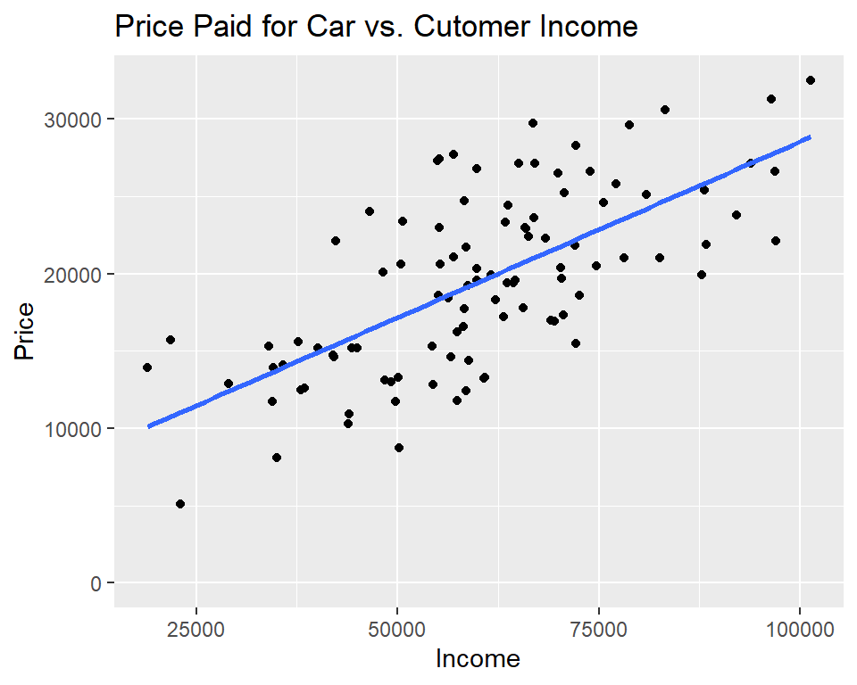

## Residual Diagnostics

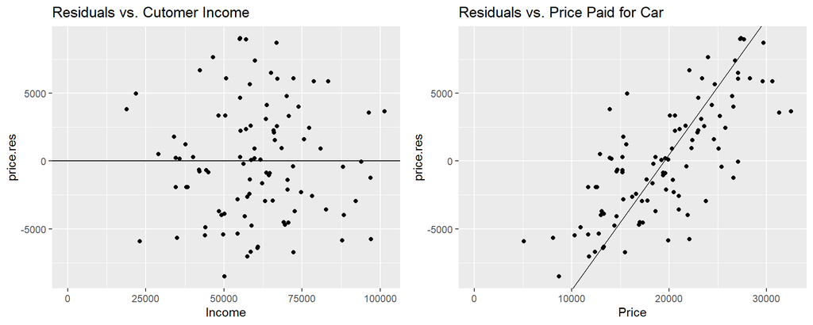

## A closer look at the code to draw the Residual Diagnostics

```r
# Provides the multiplot() command
if (!require("Rmisc")) install.packages("Rmisc")
suppressMessages(library(Rmisc))

# store the residuals in a vector
price.res = resid(price.lm)

res.income.plot <- car.price %>% ggplot(aes(x=Income,y=price.res)) +
  geom_point() +
  expand_limits(y = 0, x = 0) +
  geom_hline(yintercept=0) +
  ggtitle("Residuals vs. Cutomer Income")

res.price.plot <- car.price %>% ggplot(aes(x=Price,y=price.res)) +
  geom_point() +
  expand_limits(y = 0, x = 0) +
  geom_abline(intercept = -1*mean(car.price$Price), slope = 1) +
  ggtitle("Residuals vs. Price Paid for Car")

multiplot(res.income.plot, res.price.plot, cols=2)
```

## Fitted vs Actual Plot

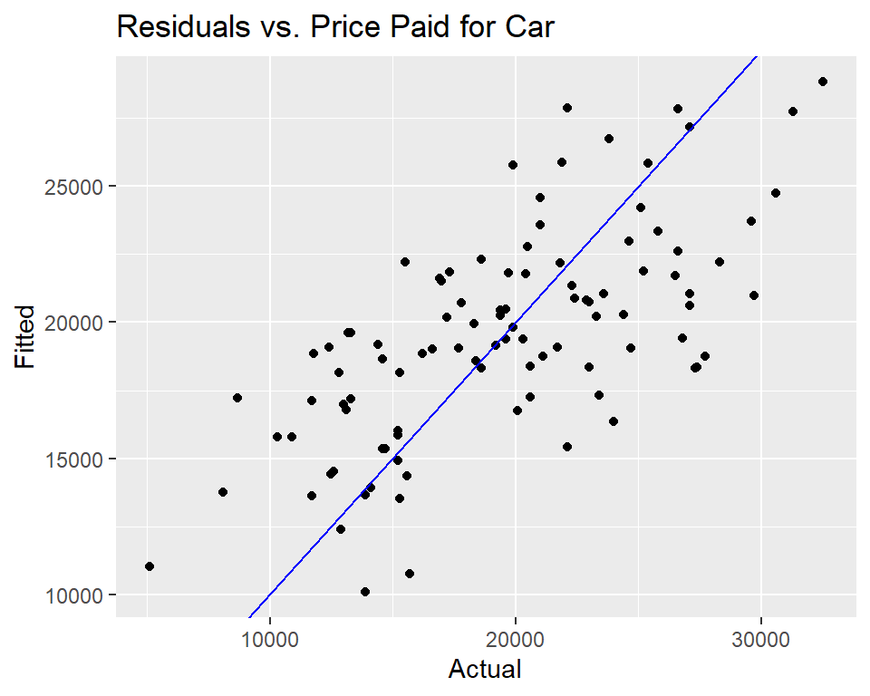

```r
price.fitted <- fitted(price.lm)
car.price %>% ggplot(aes(x=Price,y=price.fitted)) +
  geom_point() +
  geom_abline(intercept = 0, slope = 1, color = "blue") +
  xlab("Actual") +
  ylab("Fitted") +
  ggtitle("Residuals vs. Price Paid for Car")
```

## Normality of the Residuals

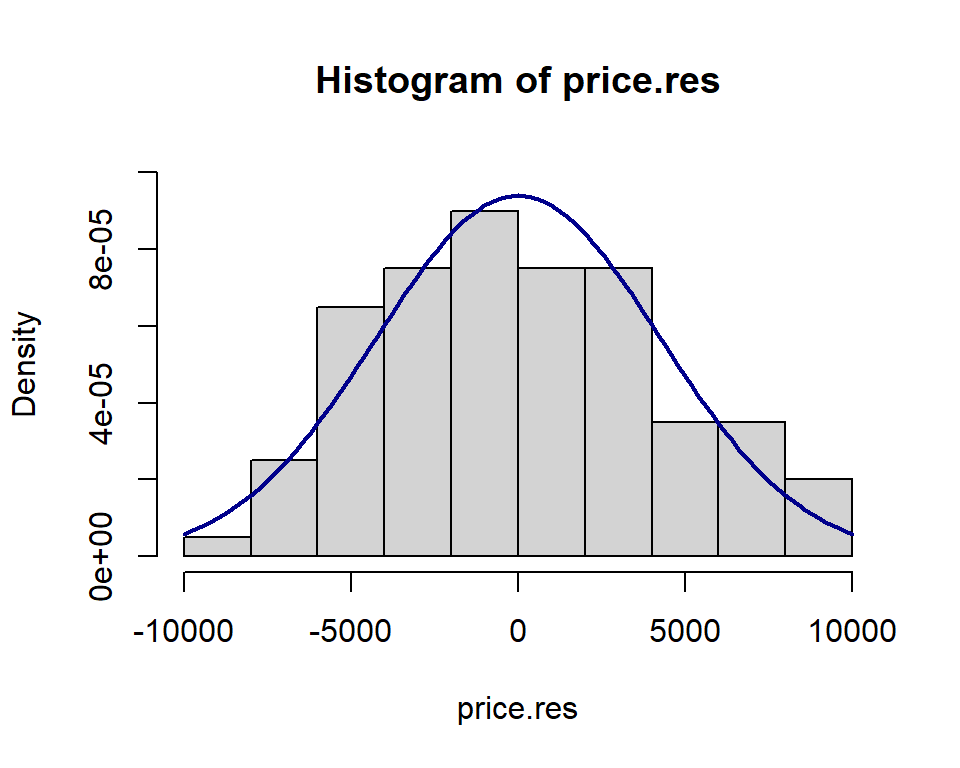

```r
hist(price.res,probability = T, ylim=c(0,.0001))
curve(dnorm(x,mean=mean(price.res),sd=(sd(price.res))),
      col="darkblue", lwd=2, add=TRUE, yaxt="n")
```